# 1. Stabilisation des données Navigo

Il s'agit d'abord de s'assurer qu'on dispose de données stables pour effectuer la projection des prix par tonneau par partenaire.

## 1.1. Analyse de Christine sorti à partir de la base postgresql durant le visusprint

Note : en relation à une première stratégie d'estimation "fine" finalement abandonnée, cette extraction présentait un compte par pays et par produit, nous avions donc des tonnages qui n'incluent pas les bateaux sans cargaison définie.

```
Agrégation des valeurs par pays à partir de l'extraction de Christine:
                     pays   tonnage
0              Angleterre  181112.0
1                Danemark   47201.0
2                 Espagne   48398.0
3     Etats de l'Empereur   42778.0
4   États-Unis d'Amérique   56971.0
5                Hollande  103274.0
6                Portugal   26846.0
7                  Prusse   25539.0
8     Villes hanséatiques  120050.0
9                  Russie   21135.0
10                  Suède   17515.0
```

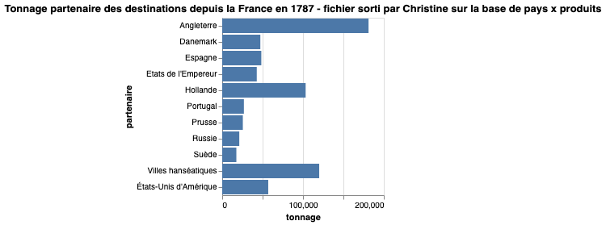

# 1.2. Test d'une seconde méthode à partir de l'API `raw_flows`

On refait le même compte en se basant sur les données disponibles en lignes via l'adresse raw_flows. On teste cette méthode pour s'assurer d'une meilleure reproductibilité pour la suite.

Filtres appliqués sur les flux navigo :

- departure_state_1789_fr = France
- departure_function = 'O'
- destination_state_1789_fr != France et destination_state_1789_fr != vide
- cargaison : on prend tous les flux sans cargaison, ou alors avec au moins une cargaison qui ne correspond pas à 'lest', 'lège', 'vide', ou 'futailles vides'

```
destinations navigo :
                     pays   tonnage
0                Danemark   40026.0
1              Angleterre  158827.0
2                  Russie   14503.0
3                 Espagne   36093.0
4                Hollande   73248.0
5                Portugal   34821.0
6     Villes hanséatiques   65623.0
7                   Suède   14059.0
8   États-Unis d'Amérique   19652.0
9     Etats de l'Empereur   28040.0
10                 Prusse   17179.0
tonnage total :  502071.0
```

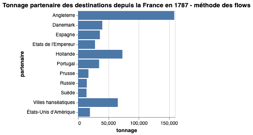

```
destinations navigo :
                     pays   tonnage
0                Danemark   40026.0
1              Angleterre  140785.0
2                  Russie   14503.0
3                 Espagne   36093.0
4                Hollande   73248.0
5                Portugal   33931.0
6     Villes hanséatiques   65623.0
7                   Suède   14059.0
8   États-Unis d'Amérique   19652.0
9     Etats de l'Empereur   28040.0
10                 Prusse   17179.0
tonnage total :  483139.0
```

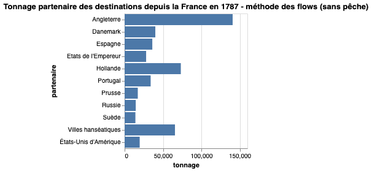

Première analyse : résultats légèrement différents par rapport à la méthode précédente, avec des tonnages généralement moins importants (est-ce à cause de l'exclusion des vides ? ou du `departure_function=O` ?)

## 1.3. Méthode à partir des pointcalls 1787

Pour controller, on teste également une méthode se basant sur les pointcalls.

Filtrage appliqué aux pointcalls :

- pointcall_type = 'In'
- state_1789_fr != France et state_1789_fr != vide
- cargaison : on prend tous les flux sans cargaison, ou alors avec au moins une cargaison qui ne correspond pas à 'lest', 'lège', 'vide', ou 'futailles vides'

```
destinations navigo:
                     pays   tonnage
0              Angleterre  172450.0
1                 Espagne   73074.0
2                   Suède   14414.0
3                  Russie   30908.0
4                Danemark   41656.0
5                Portugal   41724.0
6     Villes hanséatiques   65899.0
7   États-Unis d'Amérique   24383.0
8     Etats de l'Empereur   30001.0
9                Hollande   74365.0
10                 Prusse   17322.0
```

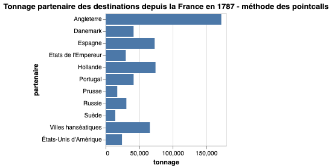

Analyse : les données sont de nouveaux lègerement différentes. À noter : on n'a pas pris en compte les in-out dans ce cas précis, c'est peut-être l'explication.

## 1.4. Source F12 récoltée par Silvia

On teste enfin la source suivante, censée donner les tonnages par destination pour les bateaux pleins partis de France en 1787 : https://docs.google.com/spreadsheets/d/1Y_7tbin8s1D_xEtwMBHXleqQUwb8rvqM550yDEEk0w4/edit#gid=249173198

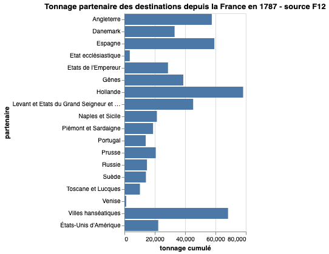

## 1.5. Conclusion de la vérification navigo

Les données de F12 sont très différentes de ce que l'on obtient avec navigo. On va utiliser cette source pour la suite.

# 2. stabilisation des données toflit18

On s'attelle maintenant à la vérification des données toflit18.

On va tester différentes sources de données pour s'assurer qu'il n'y a pas de disparités qui expliqueraient les chiffres bizarres obtenus pendant le 2ème datasprint.

## 2.1. Source "résumé"

Filtrage des flux toflit18 :

- année : 1787
- source_type : "Résumé"
- export_import : "Exports"

```
somme des exports selon résumé en 1787 :
                      partenaire     tonnage
0            Colonies françaises  95559900.0
1                        Espagne  40161200.0
2                       Hollande  33571500.0
3                         Prusse   9008500.0
4                      Allemagne  22464400.0
5                         Suisse  20531400.0
6          États-Unis d'Amérique   2050600.0
7            Villes hanséatiques  60194700.0
8                       Danemark   6334500.0
9                          Suède   5053700.0
10  Milanais, Toscane et Lucques  10847100.0
11                         Gênes   6286100.0
12    Empire Ottoman et Barbarie  25608100.0
13          Royaume de Sardaigne  19266630.0
14                      Autriche  33919600.0
15                        Russie   6630000.0
16                      Portugal   3935200.0
17         États ecclésiastiques   3421400.0
18                    Angleterre  34200500.0
19                        Naples   5355600.0
20                        Venise    894700.0
```

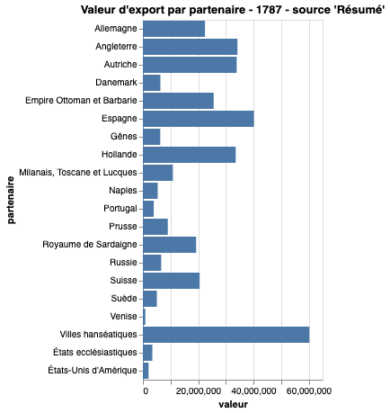

Note : après essais, on se rend compte qu'utiliser la source_type "Résumé" revient en fait exactement à utiliser `best_guess_national_partner` (au moins pour l'année 1787).

## 2.2. Méthode `best_guess_national_prodxpart`

Pour contrôler, on essaie de reproduire le calcul du total des exports fr en 1787 via les sources comprenant les produits. On aggrège toujours par partenaire.

Filtrage des flux toflit18 :

- année : 1787
- drapeau : "best_guess_national_prodxpart"
- export_import : "Exports"

```
sources utilisées:['Résumé']
partners_toflit18:
                      partenaire     tonnage
0            Colonies françaises  95559900.0
1                        Espagne  40161200.0
2                       Hollande  33571500.0
3                         Prusse   9008500.0
4                      Allemagne  22464400.0
5                         Suisse  20531400.0
6          États-Unis d'Amérique   2050600.0
7            Villes hanséatiques  60194700.0
8                       Danemark   6334500.0
9                          Suède   5053700.0
10  Milanais, Toscane et Lucques  10847100.0
11                         Gênes   6286100.0
12    Empire Ottoman et Barbarie  25608100.0
13          Royaume de Sardaigne  19266630.0
14                      Autriche  33919600.0
15                        Russie   6630000.0
16                      Portugal   3935200.0
17         États ecclésiastiques   3421400.0
18                    Angleterre  34200500.0
19                        Naples   5355600.0
20                        Venise    894700.0
```

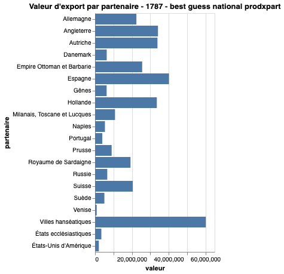

Analyse : les données sont identiques, c'est toujours la source "Résumé" qui est utilisée. Cela valide l'accès aux données toflit18 comme stable. Néanmoins subsiste un problème : les exports peuvent se faire par mer ou par terre pour certains partenaires ...

On note certains partenaires vers lesquelles une valeur particulièrement importante de marchandise a été exportée : Hollande, Villes Hanséatiques, Espagne, Angleterre.

D'un point de vue méthodologique et vis-à-vis de la suite, la question est de savoir si les échanges qui produisent ces valeurs correspondent à des échanges marins, et s'ils sont spécifiques à l'année 1787.

Avant d'aller plus loin, inspectons quels sont les produits qui produisent ces irrégularités remarquables.

### 2.3. Interlude : zoom sur les exports toflit18 nationaux par produits

On prend le temps de visualiser de quoi sont composées les valeurs du graphique précédents.

Filtrage des flux toflit18 :

- année : 1787
- drapeau : "best_guess_national_prodxpart"
- export_import : "Exports"
- partner_simplification différent de 'Colonies françaises'

Puis on visualise les valeurs par produit et partenaire agrégés selon la classification "révolution et empire" :

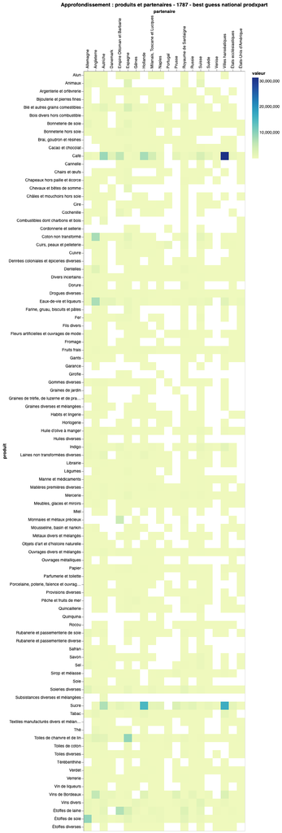

Analyse : pour l'Espagne, on voit qu'elle est l'objet d'un import de monnaies et métaux précieux depuis la France très important : après investigation, il s'agit d'un unique flux de "lingots ou monnaies étrangères d'argent et d'or" (est-il régulier sur les autres années ?).

Pour Hollande, Villes Hanséatiques, et Angleterre, on ne note pas de type de produit à la valeur exceptionnel qui pourrait représenter une irrégularité avec 1789 (?).

Il faut maintenant être capable de distinguer les flux faits par terre et par mer.

## 2.3. Utilisation de la source terre-mer

Il s'agit de distinguer, pour chaque partenaire, la portion des flux vraisemblement effectués par la mer. Cette information n'est disponible que de manière agrégée par partenaire pour 1792, on va donc utiliser une source nous donnant cette information.

Le décompte des exports par terre et par mer pour 1792 est consigné dans ce fichier google spreadsheet : https://docs.google.com/spreadsheets/d/1d0peowoVhblBWtHkGxO0V1_H201rUAWd_arI0LbPfXc/edit#gid=373560562

L'image de la source originale est ici : https://drive.google.com/file/d/1tLsLCy3Wn22IqMxRO71koSUpH4jXogVM/view?usp=sharing

On utilise cette source pour avoir une estimation des sommes d'export par la mer pour chaque partenaire de 1787, ainsi qu'une estimation du ratio terre/mer permettant d'approximer la répartition des valeurs entre terre et mer pour d'autres flux toflit18.

*Note : ce ratio est une importante approximation dans notre méthodologie, mais au vu des données ensuite concernées il n'aura pas un très gros impact sur les chiffres.*

On dispose de deux valeurs pour chaque partenaire dans la source terre-mer : les valeurs d'exports par la mer, et par la terre. On commence par visualiser la somme des deux, puis les valeurs d'exports par la mer seulement :

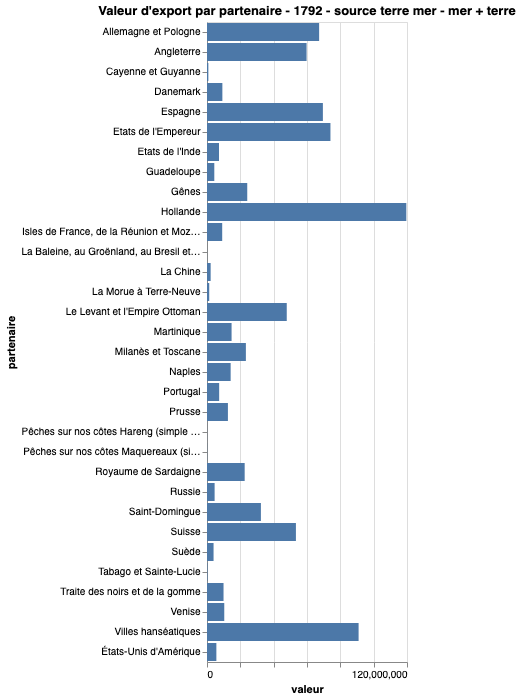

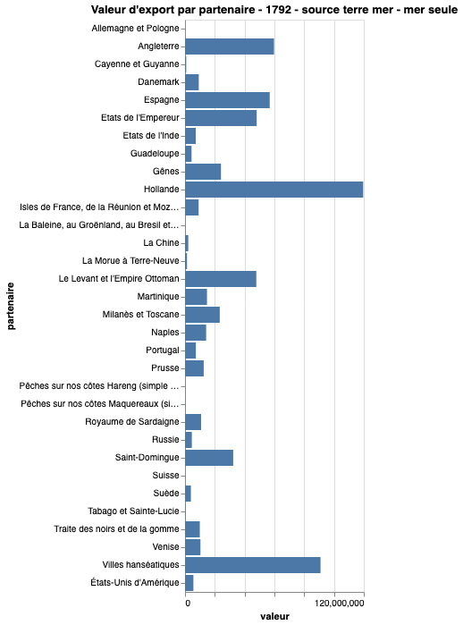

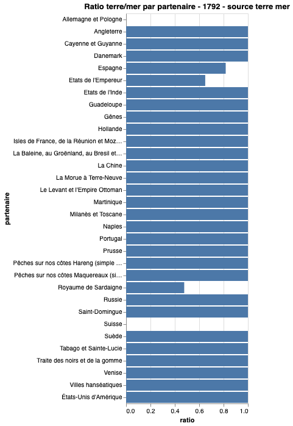

Pour affiner, il pourrait être intéressant d'aligner ces noms de partenaires avec la classification simplification. Mais au vu des données ensuite concernées pour Dunkerque, cela ne devrait pas avoir un gros impact (?).

# 3. Essais de projection

On va maintenant tester le calcul des prix par tonneau par partenaire, en utilisant les données toflit18 "Résumé" en pondérant les valeurs par le ratio terre/mer calculé grâce à la source terre-mer.

Filtrage des flux toflit18 :

- année : 1787
- source_type : "Résumé"
- export_import : "Exports"
- partner_simplification différent de 'Colonies françaises'

Filtres appliqués sur les flux navigo :

- departure_state_1789_fr = France
- departure_function = 'O'
- destination_state_1789_fr != France et destination_state_1789_fr != vide
- cargaison : on prend tous les flux sans cargaison, ou alors avec au moins une cargaison qui ne correspond pas à 'lest', 'lège', 'vide', ou 'futailles vides'

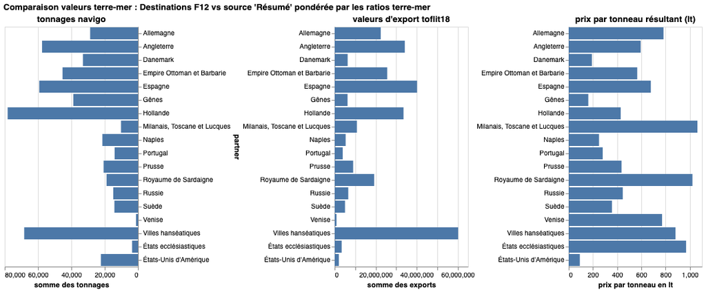

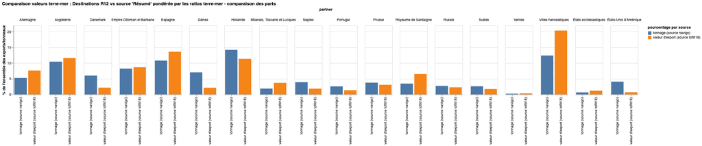

Première analyse :

La plupart des ratios tonnage/prix semblent cohérents.

Certaines detinations ont une part d'exports plus importante que leur part de tonnage, ce qui donne un important prix par tonneaux (notamment, destinations italiennes et villes hanséatiques).

On voit apparaître des pays avec une forte disparité au profit de la navigation (ce qui veut correspond à des échanges de produits peu rentables du point de vue transport) : Gênes, Danemark, Portugal, USA. Cela provoque des prix par tonneaux relativement bas.

## 3.3. Conclusion des tests pour établir le modèle

On a établi une méthode pour calculer un prix par tonneau par partenaire à partir de 1787.

Il est à noter qu'il faudra s'adapter à l'apparition de nouveaux partenaires ou destinations pour 1787 pour des flux locaux.

Il faut maintenant tester le modèle obtenu avec des données où l'on dispose à la fois de navigo et de toflit18.

# 4. Vérification du modèle sur des ensembles de données complets dans PASA

## 4.1. Test sur les données du bureau des fermes de La Rochelle en 1789

Pour tester les prix par tonneau obtenus avec notre méthode, on va les appliquer aux départs du port de La Rochelle en 1789, et les comparer aux exports cumulés toflit18 pour le bureau des fermes de La Rochelle la même année.

**On s'attend à avoir des valeurs similaires par partenaires entre la valeur calculée et la valeur des sources toflit18.** Plus la valeur calculée et la valeur sont "proches", plus on s'assure que la projection sur Dunkerque est crédible.

### 4.1.1. Analyse préliminaire des données

On commence par visualiser la répartition des destinations des trajets pour le port de La Rochelle en 1789.

Filtres appliqués sur les flux navigo 1789 :

- departure_ferme_bureau = La Rochelle
- departure_function = 'O'
- destination_state_1789_fr != France et destination_state_1789_fr != vide
- cargaison : on prend tous les flux sans cargaison, ou alors avec
  - au moins une cargaison qui ne correspond pas à 'lest', 'lège', 'vide', ou 'futailles vides'
  - aucune cargaison correspondant à de la pêche (commodity_id : ['00000012', '00000240', '00000240','00000280', '00000306', '00000307', '00000328', '00000329', '00000331', '00000332', '00000336',])

```
Destinations selon navigo (en tonneaux) :
             destination  tonnage
0    Villes hanséatiques   1050.0
1             Angleterre   1048.0
2    Etats de l'Empereur    512.0
3               Danemark    150.0
4                 Prusse    370.0
5               Hollande    550.0
6  États-Unis d'Amérique    160.0
7               Portugal    584.0
Tonnage moyen des navires : 126.4
```

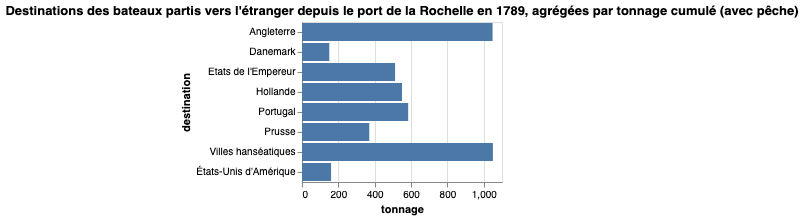

```
Destinations selon navigo (en tonneaux) :
             destination  tonnage
0    Villes hanséatiques   1050.0
1             Angleterre   1048.0
2    Etats de l'Empereur    512.0
3               Danemark    150.0
4                 Prusse    370.0
5               Hollande    550.0
6  États-Unis d'Amérique    160.0
7               Portugal    584.0
Tonnage moyen des navires : 126.4
```

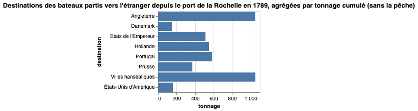

On visualise ensuite les flux d'export du bureau des fermes de La Rochelle.

Filtrage des flux toflit18 :

- année : 1789
- customs_office : 'La Rochelle'
- drapeau 'best_guess_region_prodxpart' (flux avec direction des fermes, produit et partenaire)
- export_import : "Exports"
- partner_grouping différent de 'France'
- partner_simplification différent de 'Colonies françaises', 'Îles françaises de l\'Amérique', 'Sénégal', 'Saint-Domingue'

On visualise les valeurs d'export brutes, puis les valeurs d'export pondérées par les ratios terre-mer par partenaire calculé grâce à la source terre-mer.

```
Ratio : le partenaire suivant n'a pas été trouvé dans les ratios, il sera considéré comme 100% mer :  Monde hors colonies
Ratio : le partenaire suivant n'a pas été trouvé dans les ratios, il sera considéré comme 100% mer :  Indes

Partenaires selon toflit18 (en livre tournois) - non corrigé avec terre-mer :
            partenaire  valeur exports
0  Monde hors colonies    5.136098e+06
1  Villes hanséatiques    1.064053e+04
2  Etats de l'Empereur    3.343824e+03
3               Prusse    2.776752e+03
4                Indes    3.806000e+04
```

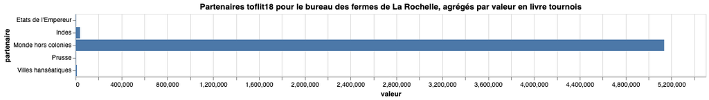

```
Partenaires selon toflit18 (en livre tournois) - corrigé avec terre-mer :
            partenaire  valeur exports
0  Monde hors colonies    5.136098e+06
1  Villes hanséatiques    1.064053e+04
2  Etats de l'Empereur    2.172075e+03
3               Prusse    2.776752e+03
4                Indes    3.806000e+04
```

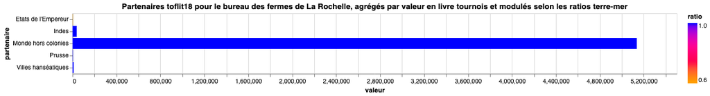

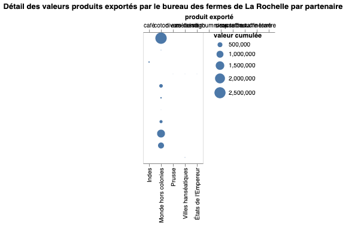

On compare maintenant les parts relatives des valeurs d'exports toflit18 et des tonnages cumulés navigo par partenaire pour vérifier qu'on ne détecte pas de bizarreries à ce stade avant d'appliquer le modèle :

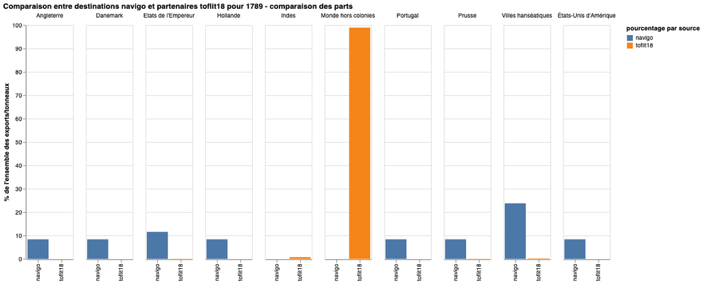

Première analyse : à cause de "monde hors colonies" ce graphique ne donne pas grand chose car la plupart des exports toflit18 correspondent à "Monde hors colonies".

Questions :

- pourquoi n'a-t-on aucune navigation vers le Sénégal dans F12 ?
- à quoi devrait correspondre Saint-Domingue dans les destinations navigo ?

### 4.1.2. Test du modèle

On fait maintenant le test en appliquant les prix par tonneau calculés pour la France en 1787 aux destinations du port de La Rochelle en 1789.

On tente d'aggréger les flux toflit18 de la source 'Résumé' puis les pondérer avec les ratios terre-mer, et on calcule le prix par tonneau en se basant sur la source F12 pour ce qui est de la navigation.

On obtient les valeurs d'export en livres tournois suivantes :

```
Ratio : le partenaire suivant n'a pas été trouvé dans les ratios  Monde hors colonies
Ratio : le partenaire suivant n'a pas été trouvé dans les ratios  Indes
partenaires toflit18 pour la rochelle :
            partenaire  valeur d'export  valeur d'export pondérée
0  Monde hors colonies     5.136098e+06              5.136098e+06
1  Villes hanséatiques     1.064053e+04              1.064053e+04
2  Etats de l'Empereur     3.343824e+03              2.172075e+03
3               Prusse     2.776752e+03              2.776752e+03
4                Indes     3.806000e+04              3.806000e+04
                      partenaire toflit18 estimation  source/estimation
0                       Danemark        0     28,750                  /
1                     Angleterre        0    622,659                  /
2                         Russie        0          0                  /
3                        Espagne        0          0                  /
4                       Hollande        0    236,074                  /
5                       Portugal        0    164,072                  /
6            Villes hanséatiques   10,640    925,706  87.00244360902256
7                          Suède        0          0                  /
8          États-Unis d'Amérique        0     14,731                  /
9                      Allemagne        0          0                  /
10                        Prusse    2,776    161,458   58.1621037463977
11          Royaume de Sardaigne        0          0                  /
12                         Gênes        0          0                  /
13  Milanais, Toscane et Lucques        0          0                  /
14         États ecclésiastiques        0          0                  /
15                        Naples        0          0                  /
16                        Venise        0          0                  /
17    Empire Ottoman et Barbarie        0          0                  /
```

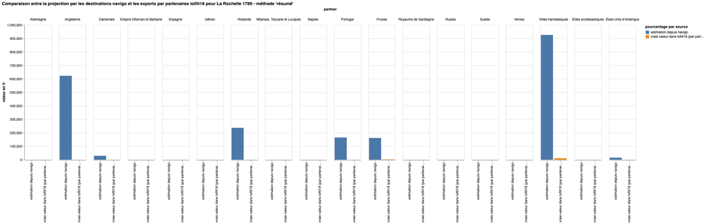

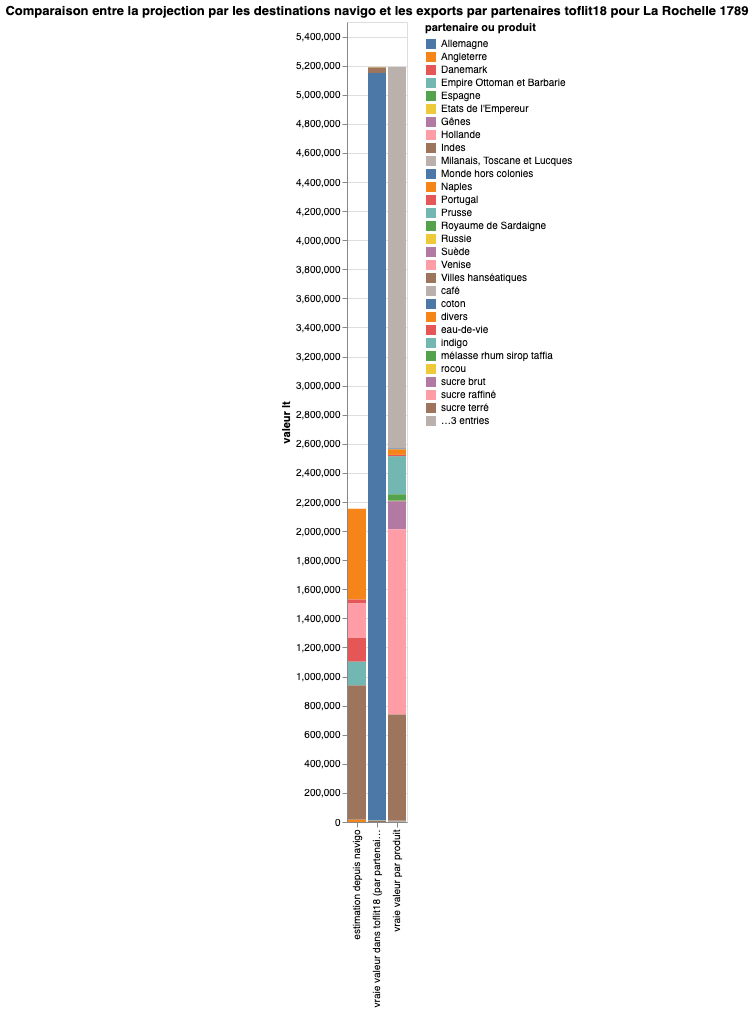

```
Total des exports en lt selon la projection : 2,153,452
Total des exports en lt selon toflit18 (brut) : 5,190,919
Total des exports en lt selon toflit18 (corrigée) : 5,189,747
rapport projection/réalité : 0.4149435857818172
```

Première analyse :

- les comparaisons par destinations ne donnent rien à cause de "monde hors colonies"
- la projection globale sous-estime de 2 fois les exports tels que décrits par toflit18.

On suppose que la différence est due au fait que le café et le sucre sont largement surreprésentés dans les exports de La Rochelle.

Éprouvons maintenant la méthode en refaisant le test avec d'autres ports/bureaux de ferme.

## 4.2. Test sur les ports du bureau des fermes de Saint-Martin-de-Ré

```
Destinations selon navigo (en tonneaux) :
             destination  tonnage
0  États-Unis d'Amérique   2227.0
1               Danemark   4277.0
2             Angleterre   3942.0
3                Espagne    297.0
4               Hollande   2463.0
5    Villes hanséatiques   1815.0
6    Etats de l'Empereur    150.0
7                 Prusse   1000.0
8                 Russie    176.0
Ports pris en compte pour le bureau : Saint Martin de Ré, Ars en Ré, La Flotte en Ré
Tonnage moyen des navires : 124.78625954198473
```

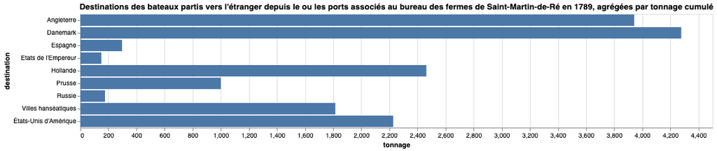

```
scan des valeurs pour le bureau des fermes de Saint-Martin-de-Ré
flux bruts toflit18 :
              partenaire         valeur
0             Angleterre   56529.897897
1               Hollande   41338.311326
2    Villes hanséatiques  110739.077552
3               Danemark  201724.816482
4  États-Unis d'Amérique   47357.640000
5                 Prusse   16788.863897
6                 Russie   23034.000000
7                Espagne    5500.799809
8    Etats de l'Empereur     575.135951
9                  Suède    6009.983503
```

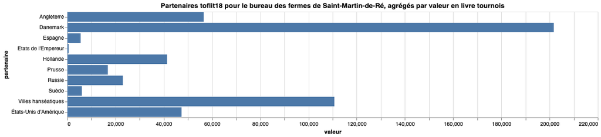

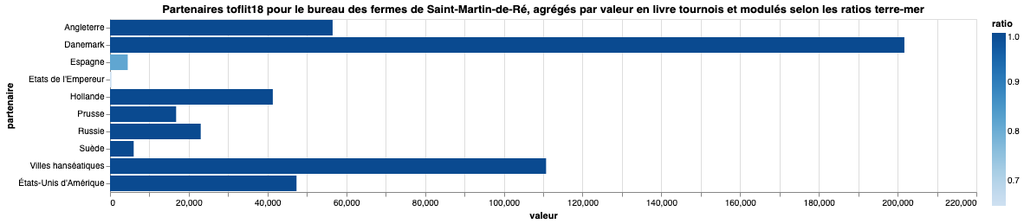

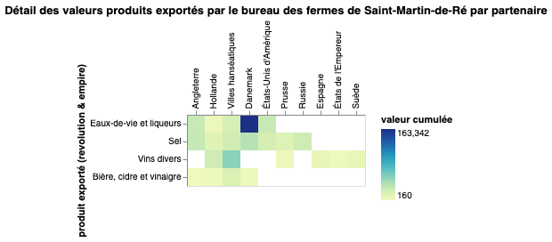

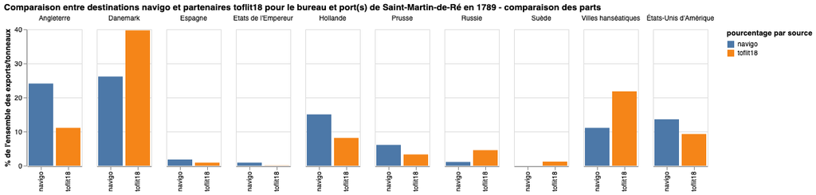

```
Correspondance résumé :
                         partner  sum_tonnage   sum_exports  price_per_barrel
0                       Danemark      33049.0  6.334500e+06        191.669945
1                     Angleterre      57563.0  3.420050e+07        594.140333
2                         Russie      14848.0  6.630000e+06        446.524784
3                        Espagne      59250.0  3.283826e+07        554.232315
4                       Hollande      78214.0  3.357150e+07        429.226225
5                       Portugal      14007.0  3.935200e+06        280.945242
6            Villes hanséatiques      68277.0  6.019470e+07        881.624852
7                          Suède      14161.0  5.053700e+06        356.874515
8          États-Unis d'Amérique      22271.0  2.050600e+06         92.074896
9                      Allemagne      28703.0  2.246440e+07        782.649897
10                        Prusse      20644.0  9.008500e+06        436.373765
11          Royaume de Sardaigne      18869.0  9.191349e+06        487.113755
12                         Gênes      38779.0  6.286100e+06        162.100621
13  Milanais, Toscane et Lucques      10210.0  1.084710e+07       1062.399608
14         États ecclésiastiques       3531.0  3.421400e+06        968.960634
15                        Naples      21383.0  5.355600e+06        250.460646
16                        Venise       1161.0  8.947000e+05        770.628768
17    Empire Ottoman et Barbarie      45285.0  2.560810e+07        565.487468
```

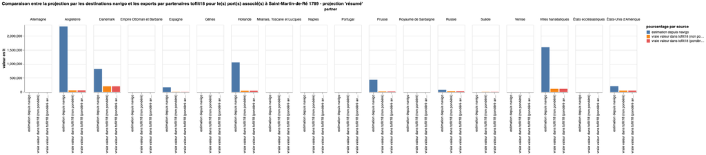

```
Total des exports en lt selon la projection 'résumé' : 6,703,826 lt
Total des exports en lt selon toflit18 : 509,598 lt
Total des exports en lt selon toflit18 (corrigé avec ratios terre-mer) : 508,393 lt
Méthode 'résumé' - rapport projection/réalité : facteur de 13.186282783547941
```

Hypothèses d'explication :

- ces ports commercent des produits de bien plus faible valeur que la moyenne française. Ou les bateaux partent très peu chargés.
- étant donné d'une part que les bateaux qui partent de ces ports ont des tonnages importants, et d'autre part qu'on les suppose toujours pleins, on surestime la valeur.

NB : dans l'itération précédente de ce travail, on était à 22 fois plus, il y a donc du mieux !

On fait l'hypothèse que la grande différence de ratio par rapport à la projection est dûe au sel. On va donc représenter les produits par poids (on prend également les litres en supposant que les liquides ont un poids similaire à l'eau).

```
nombre de flux pour le bureau des fermes de Saint-Martin-de-Ré :  25
nombre de flux avec poids :  25
représentativité en nombre de flux : 100.0%
```

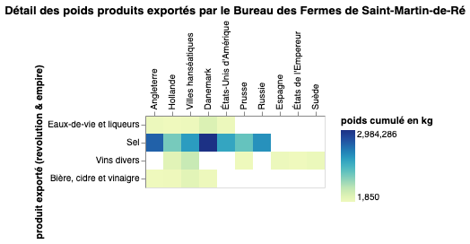

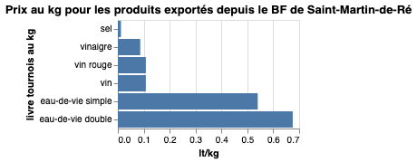

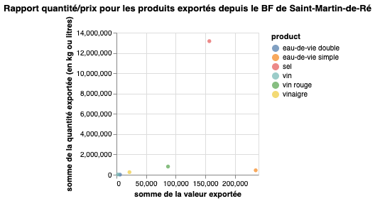

Ces visualisations confirment notre hypothèse selon laquelle le commerce du sel est la source de la surestimation produite par la projection.